# **第六章：典型排序 – Canonical Ordination | 约束性排序**

```r
# PRC plot; 仅报告了具有大的总（对数转换）丰度的物种
(logabu <- colSums(pyrifos))
```

```
##    Simve    Daplo    Cerpu    Alogu    Aloco    Alore    Aloaf    Copsp
##  453.250  186.893   71.197   44.619   12.530   49.473   49.100  365.331
##    Ostsp    Slyla    Acrha    Aloex    Chysp    Alona    Plead    Oxyte
##  408.031   94.949   26.886   28.846   84.685    5.411   13.388    3.178
##    Grate    Copdi    NauLa    CilHa    Strvi    amosp    Ascmo    Synsp
##    8.722  172.570  706.613 1610.902  731.774  612.886  339.663  739.394
##    Squro    Squmu    Polar    Kerqu    Anufi    Mytve    Mytvi    Mytmu
##   78.296   17.291  839.171   32.364   23.842   38.296    9.230   23.075
##    Lepsp    Leppa    Colob    Colbi    Colun    Lecsp    Lecqu    Lecco
##  148.537   19.148   95.262   30.846  121.494  136.140  126.130   81.821
##    Leclu    Lecfl    Tripo    Cepsp    Monlo    Monae    Scalo    Trilo
##   54.208  134.975   13.845  304.377   33.681   44.978   36.436    9.230
##  Tripo.1    Tricy    Trisp    Tepat    Rotne    Notla    Filsp    Lopox
##   34.369   45.956    9.230   23.763    4.615   32.305    4.615    9.230
## hydrspec bothrosp olchaeta erpoocto glsicomp alglhete hebdstag  sphidae
##    7.059  134.481  751.169  642.015  157.268  244.857  238.470  261.215
## ansuvote armicris bathcont binitent gyraalbu hippcomp lymnstag lymnaes7
##    5.340  664.330    2.353  397.338   32.297   35.167   34.066   18.101
## physfont plbacorn popyanti radiovat radipere valvcris valvpisc hycarina
##    5.340    6.357  160.213    2.987   81.198    2.353  181.676  242.773
## gammpule aselaqua proameri collembo caenhora caenluct caenrobu cloedipt
##  123.895  231.419    5.340    2.353  787.532  228.399    9.412  831.926
## cloesimi aeshniae libellae conagrae corident coripanz coripunc cymabons
##  129.718  118.758   27.251  597.239    4.706   19.641   58.378    4.706
## hesplinn hespsahl notoglau notomacu notoobli notoviri pacoconc pleaminu
##   10.046    2.353   42.248   18.786   21.811   42.920    2.353    2.353
## sigadist sigafall sigastri sigarasp colyfusc donacis6 gyrimari haliconf
##    7.693   24.164   20.092    8.327    2.353    2.353    2.353   52.966
## haliflav haligruf haliobli herubrev hya_herm hyglpusi hyhyovat hypoplan
##    4.706   82.201   22.445    4.706   27.215    2.353   20.092    2.353
## hyporusp hytuinae hytuvers laphminu noteclav rhantusp sialluta ablalong
##   11.063  219.752  169.323  175.742    4.706    2.353   87.911    2.353
## ablaphmo cltanerv malopisp mopetenu prdiussp pstavari chironsp crchirsp
##  392.080   30.632    2.353    3.644  130.340    7.693  305.594    2.353
## crclglat ditendsp mitegchl pachgarc pachgvit popegnub popedisp acriluce
##    2.353    9.523   31.878    4.706    2.353   20.726    5.340    4.034
## chclpige conescut cricotsp liesspec psclbarb psclgsli psclobvi psclplat
##    2.353   60.521    6.357    4.706    2.353  158.219   69.491   11.588
## psclpsil pscladsp cladotsp laa_spec patanysp tatarssp zaa_spec anopmacu
##    2.353    8.076   76.562    2.353   13.690  130.125    4.706    6.387
## cepogoae chaoobsc cucidae4 tabanusp agdasphr athrater cyrncren holodubi
##  300.840  426.900    2.353    7.693  147.572    2.353    2.353   21.811
## holopici leceriae lilurhom monaangu mystazur mystloni oecefurv oecelacu
##  106.509   16.471    7.059   80.495    2.353  510.566   27.534   19.030
## triabico paponysp
##    7.693   56.954
```

```r
class(logabu) # 向量
```

```
## [1] "numeric"
```

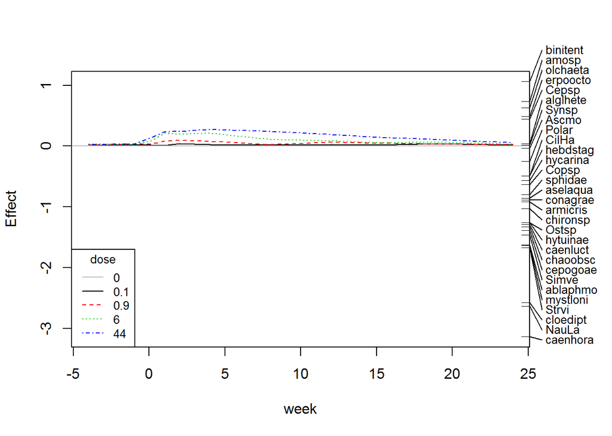

```r
plot(mod, select = logabu > 200)
```

```r
# 统计检验
# 因子 ditches 随机化; 时间序列, 仅对第一轴感兴趣
ctrl <-
  how(plots = Plots(strata = ditch, type = "free"),
      within = Within(type = "series"),
      nperm = 999)
anova(mod,
      permutations = ctrl,
      first = TRUE)
```

```
## Permutation test for rda under reduced model
## Plots: ditch, plot permutation: free
## Permutation: series
## Number of permutations: 999
##
## Model: prc(response = pyrifos, treatment = dose, time = week)
##          Df Variance      F Pr(>F)
## RDA1      1   25.282 15.096  0.001 ***
## Residual 77  128.959
## ---
## Signif. codes:  0 '***' 0.001 '**' 0.01 '*' 0.05 '.' 0.1 ' ' 1
```

### 6.6.2 协对应分析(Co-correspondence Analysis, CoCA)

协对应分析是基于对应分析发展的一种分析方法, 对相同位点的两个群落进行同时排序. 不对称分析的形式可允许通过一个群落预测另一个. 这种方法填补了一个分析空白: 生态学家通过多种不同类型的环境变量数据的均值(或者采用反向校正和预测的方法)来解释群落数据, 通过生物指标物种或群落来估算环境变量的价值.

(在对称的分析模式中, 两个群落之间没有解释和被解释的关系)

cocorresp 分析包, 既可以进行对称分析(Symmetric), 又可以进行非对称分析( asymmetric).

```r
data(bryophyte)
data(vascular)
# method = "predictive" 默认
# method = c("predictive", "symmetric") 预测 & 对称
# https://www.rdocumentation.org/packages/cocorresp/versions/0.4-0/topics/coca
# 拟合共对应分析模型 - 共对应分析(Co-correspondence Analysis, CoCA)
(carp.pred <- coca(bryophyte ~ .,
                   data = vascular))
```

```
##
## Predictive Co-Correspondence Analysis
##
## Call: predcoca.simpls(y = y, x = x, R0 = weights, n.axes = n.axes,
## nam.dat = nam.dat)
##
## Co-CA Method: simpls
##
##                Role Variance
## bryophyte Predictor    3.113
## vascular   Response    3.471
```

```r
# 留一交叉验证 - Leave-one-out cross-validation
# 预测性共对应分析的交叉验证
# https://www.rdocumentation.org/packages/cocorresp/versions/0.4-0/topics/crossval
crossval(bryophyte, vascular)
```

[output not shown]

[output cut: 15 more lines]

[output not shown]

```
##
## Cross-validation for Predictive Co-Correspondence Analysis
##
## Call: crossval(y = bryophyte, x = vascular)
##
## Cross-validatory %fit of vascular to bryophyte:
##
##  COCA1   COCA2   COCA3   COCA4   COCA5   COCA6   COCA7   COCA8   COCA9
## 17.860  24.824  26.184  26.600  28.299  28.164  27.137  25.500  24.624
## COCA10  COCA11  COCA12  COCA13  COCA14  COCA15  COCA16  COCA17  COCA18
## 24.555  24.029  23.106  22.937  21.188  20.404  19.847  20.979  19.451
## COCA19  COCA20  COCA21  COCA22  COCA23  COCA24  COCA25  COCA26  COCA27
## 17.953  17.449  17.216  13.696  13.029  13.451  12.469  11.129   9.683
## COCA28  COCA29
##  8.352   8.417
```

```r
# 置换检验 - Permutation test
(carp.perm <- permutest(carp.pred,
                        permutations = 99))
```

[output not shown]

```
##
## Permutation test for predictive co-correspondence analysis:
##
## Call: permutest.coca(x = carp.pred, permutations = 99)
##
## Permutation test results:
##
##            Stat.  Inertia      Fit    % fit P-value
## COCA 1   0.26165  3.47127  0.71990 20.73880    0.01
## COCA 2   0.13845  2.75137  0.33461  9.63939    0.01
## COCA 3   0.06870  2.41676  0.15536  4.47547    0.17
## COCA 4   0.06691  2.26141  0.14181  4.08535    0.40
## COCA 5   0.07757  2.11959  0.15257  4.39529    0.44
## COCA 6   0.06758  1.96702  0.12452  3.58718    0.79
## COCA 7   0.06712  1.84250  0.11589  3.33846    0.40
## COCA 8   0.05860  1.72661  0.09559  2.75361    0.79
## COCA 9   0.05081  1.63103  0.07886  2.27176    0.94
## COCA 10  0.05208  1.55217  0.07684  2.21361    1.00
## COCA 11  0.05762  1.47533  0.08037  2.31535    0.92
## COCA 12  0.06305  1.39496  0.08274  2.38347    0.83
## COCA 13  0.06925  1.31222  0.08498  2.44811    0.69
## COCA 14  0.05462  1.22724  0.06356  1.83114    0.89
## COCA 15  0.05560  1.16368  0.06129  1.76556    0.96
## COCA 16  0.05586  1.10239  0.05832  1.68017    0.99
## COCA 17  0.06790  1.04406  0.06639  1.91247    0.71
## COCA 18  0.06411  0.97768  0.05891  1.69698    0.93
## COCA 19  0.05620  0.91877  0.04889  1.40836    0.99
## COCA 20  0.04454  0.86988  0.03709  1.06856    1.00
## COCA 21  0.04683  0.83279  0.03726  1.07324    1.00
## COCA 22  0.04640  0.79553  0.03527  1.01620    1.00
## COCA 23  0.05590  0.76026  0.04025  1.15954    1.00
## COCA 24  0.07033  0.72001  0.04731  1.36294    0.98
## COCA 25  0.04559  0.67270  0.02933  0.84499    1.00
## COCA 26  0.06559  0.64337  0.03960  1.14084    0.97
## COCA 27  0.05993  0.60376  0.03414  0.98351    0.99
## COCA 28  0.06300  0.56962  0.03376  0.97253    1.00
## COCA 29  0.06196  0.53586  0.03127  0.90071    1.00
```

```r
# 改装(refit) - 只有两个重要的轴
(carp.pred <- coca(bryophyte ~ .,
                   data = vascular,
                   n.axes = 2))
```

```
##
## Predictive Co-Correspondence Analysis
##
## Call: predcoca.simpls(y = y, x = x, R0 = weights, n.axes = n.axes,
## nam.dat = nam.dat)
##
## Co-CA Method: simpls
##
##                Role Variance
## bryophyte Predictor    3.113
## vascular   Response    3.471
```

```r
# 提取信息- -位点得分 & 物种符合 species loadings
# https://www.rdocumentation.org/packages/cocorresp/versions/0.4-0/topics/loadings
# loadings - 从拟合的对象中提取物种负荷
carp.scores <- scores(carp.pred)
load.bryo <- carp.pred$loadings$Y
load.plant <- carp.pred$loadings$X
```

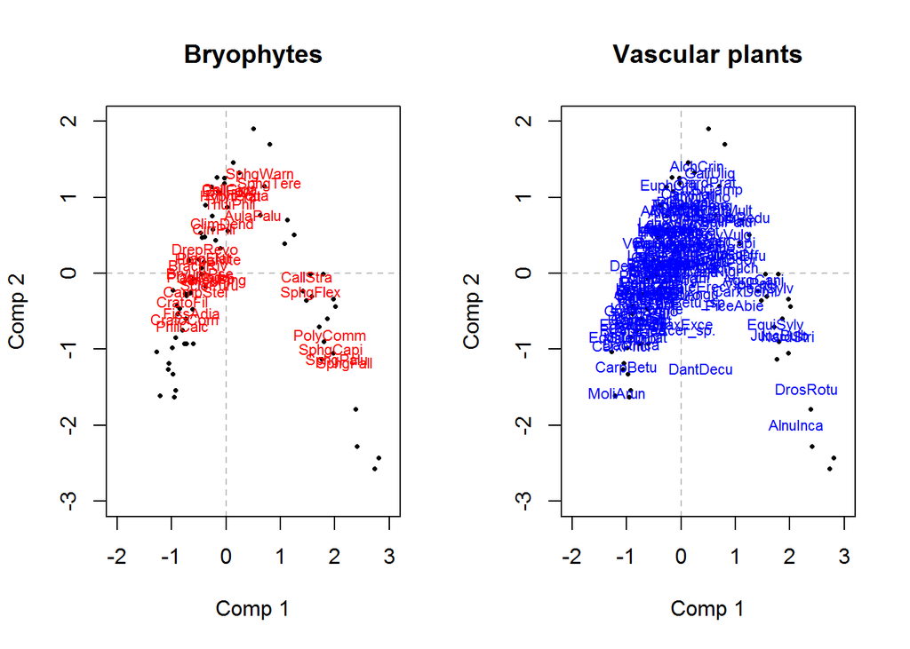

```r
# ?plot.predcoca
# https://www.rdocumentation.org/packages/cocorresp/versions/0.4-0/topics/plot.predcoca
# 绘制响应值和预测值的双序图(该部分结果来自预测性协同对应分析, co-correspondence analysis)
par(mfrow = c(1, 2))
plot(carp.pred,
  type = "none",
  main = "Bryophytes",
  xlim = c(-2, 3),
  ylim = c(-3, 2)
  )
points(carp.scores$sites$X,
       pch = 16,
       cex = 0.5)
text(load.bryo,
  labels = rownames(load.bryo),
  cex = 0.7,
  col = "red"
  )
plot(carp.pred,
  type = "none",
  main = "Vascular plants",
  xlim = c(-2, 3),
  ylim = c(-3, 2)
  )
points(carp.scores$sites$X,
       pch = 16,
       cex = 0.5)
text(load.plant,
  labels = rownames(load.plant),
  cex = 0.7,
  col = "blue"
  )
```

```r
# 未避免分析包中函数的使用冲突, 接触 cocorresp 分析包的调用
# Detach package cocorresp to avoid conflicts with ade4:
detach("package:cocorresp", unload = TRUE)
# 或者
unloadNamespace("cocorresp")
```

## 6.7 两个(或者多个数据集)的对称分析(Symmetric Analysis)

对称分析, 意味着两个或者多个矩阵在分析过程中扮演相同的角色, 它们之间既不依赖也不相互解释. 对称和非对称排序方法的选择取决于是要进行相关性分析(对称)还是要进行回归分析(非对称). 相关性分析需要更多的描述性或者解释性信息, 当模型中没有嵌入单向因果假设时亦可适用; 然而, 回归性分析具有更多的推断性判断, 通过解释性变量之间的线性组合来解释响应变量的变化. 两种分析方法源于不同的分析目的, 不应该相互对立而存在.

在生态学研究中, 存在三种对称性分析方法: 1-> 典型相关分析 canonical correlation analysis (CCorA), 2-> 共惯性分析 co-inertia analysis (CoIA), 3-> 多因子分析 multiple factor analysis (MFA).

## 6.8 典型相关分析(Canonical Correlation Analysis, CCorA)

### 6.8.1 简介

CCorA 由两个数据表计算而来, 该方法的目的是表示沿典型轴的观测值, 该观测值可以最大化两个表之间的相关性; 该方法通过最大限度地利用两组变量之间的协方差矩阵()来表示两组变量之间的 组内离散度. 两组变量必须是定量的, 而且是呈多元正态分布的; 两个数据矩阵中的变量总量必须小于 n-1. 在 CCorA 分析中, 还可以检验两个多元数据集的线性独立性假设.

RDA 和 CCA 两种分析方法的使用使得 CCorA 在生态学研究使用较少, 原因在于多数的生态学问题会优先采用不对称排序的方式从处理(控制)-反应假设的角度来进行描述的.

CCorA 更适合进行探索性分析或者探索两组变量可能相互影响的案例(这种问题多见于真实的生态问题中), 比如两组竞争性类群的研究, 还有群落定植过程中土壤-植被之间相互关系的长期研究. (在每个数据表中的物种数量都小于 n-1 的情况下进行 CCorA 才有可能).

### 6.8.2 使用 CCorA() 进行典型相关分析(Canonical Correlation Analysis)

研究两个完整的解释性变量子集之间的相关关系. CCorA 分析中会自动对数据进行标准化. 使用 vegan 工具包中的 CCorA() 函数.

```r
# 数据预处理 - 转换使变量分布近似对称(transformations to make variable distributions approximately symmetrical)
envchem2 <- envchem
envchem2$pho <- log(envchem$pho)
envchem2$nit <- sqrt(envchem$nit)
envchem2$amm <- log1p(envchem$amm)
envchem2$bod <- log(envchem$bod)
envtopo2 <- envtopo
envtopo2$ele <- log(envtopo$ele)
envtopo2$slo <- log(envtopo$slo)
envtopo2$dis <- sqrt(envtopo$dis)

# 对标准化的变量进行典型相关分析 CCorA
# https://www.rdocumentation.org/packages/vegan/versions/2.4-2/topics/CCorA
# CCorA, Canonical Correlation Analysis 典型相关分析
(chem.topo.ccora <-
  CCorA(envchem2, envtopo2,
        stand.Y = TRUE,
        stand.X = TRUE,
        permutations = how(nperm = 999))) # 置换检验
```

```
##
## Canonical Correlation Analysis
##
## Call:
## CCorA(Y = envchem2, X = envtopo2, stand.Y = TRUE, stand.X = TRUE,      permutations = how(nperm = 999))
##
##              Y X
## Matrix Ranks 7 3
##
## Pillai's trace:  1.820765
##
## Significance of Pillai's trace:
## from F-distribution:   1.1437e-06
## based on permutations: 0.001
## Permutation: free
## Number of permutations: 999
##
##                        CanAxis1 CanAxis2 CanAxis3
## Canonical Correlations  0.92091  0.76398   0.6237
##
##                      Y | X  X | Y
## RDA R squares      0.49186 0.7820
## adj. RDA R squares 0.43088 0.7094
```

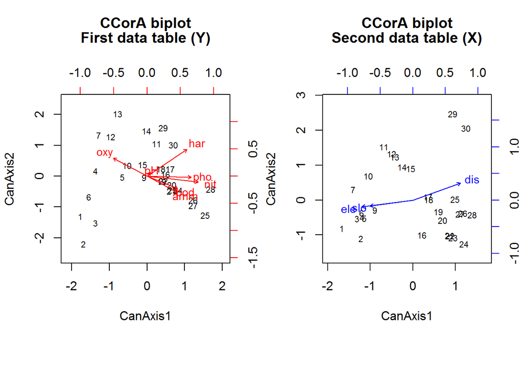

```r
biplot(chem.topo.ccora,
       plot.type = "biplot")
```

## 6.9 共惯性分析(Co-inertia Analysis, CoIA)

### 6.9.1 简介

CoIA 是 CCorA() 的一种替代方法(同属于对称性分析方法, 只做变量之间的相关性, 不做变量之间的相互解释), 对于两个或者多个数据集之间的分析更加灵活.

CoIA 分析的使用: 1-> 计算两个数据集中变量交叉的协方差矩阵, 协方差的平方和 视为 总 co-inertia. 计算特征值和特征向量的矩阵. 特征值代表 总co-inertia 的某一部分. 2-> 将两个原始数据表的对象和变量投影到共惯量轴上; 通过图的形式上, 比较两个数据表在共惯量空间中的投影.

CoIA 需要输入 位点-变量 类型的矩阵数据.

### 6.9.2 使用 ade4 分析包的 coinertia() 进行共惯性分析(Co-inertia Analysis)

由于原处的技术设计原因, 在使用 ade4 工具包进行 coinertia() 分析之前, 首先使用 dudi.pca() 函数进行 PCA 预分析, 或者使用 dudi.pco() 函数进行 PCoA 预分析.

> 两个不同的矩阵变量之间的连线, 表示相关关系, 连线越短则相关性越高 (对称性分析, 不作变量之间的解释, 仅作变量之间的关联)

```r
# 使用 ade4 中的函数进行主成分分析
dudi.chem <- dudi.pca(envchem2,
         scale = TRUE,
         scannf = FALSE)
dudi.topo <- dudi.pca(envtopo2,
         scale = TRUE,
         scannf = FALSE)
# 特征值的累积相对变化
cumsum(dudi.chem$eig / sum(dudi.chem$eig))
```

```
## [1] 0.6208588 0.7960044 0.8977378 0.9455820 0.9685968 0.9865157 1.0000000
```

```r
# 特征值的累积相对变化
cumsum(dudi.topo$eig / sum(dudi.topo$eig))
```

```
## [1] 0.8936806 0.9891719 1.0000000
```

```r
# 行 权重是否相等 ?
all.equal(dudi.chem$lw, dudi.topo$lw)
```

```
## [1] TRUE
```

```r
# 共惯性分析 - Co-inertia analysis
# https://www.rdocumentation.org/packages/cocorresp/versions/0.4-0/topics/coinertia
# coinertia 对两个表进行双惯性分析
coia.chem.topo <- coinertia(dudi.chem, dudi.topo,
            scannf = FALSE,
            nf = 2)
summary(coia.chem.topo)
```

```
## Coinertia analysis
##
## Class: coinertia dudi
## Call: coinertia(dudiX = dudi.chem, dudiY = dudi.topo, scannf = FALSE,
##     nf = 2)
##
## Total inertia: 6.853
##
## Eigenvalues:
##     Ax1     Ax2     Ax3
## 6.78059 0.05642 0.01620
##
## Projected inertia (%):
##     Ax1     Ax2     Ax3
## 98.9404  0.8233  0.2364
##
## Cumulative projected inertia (%):
##     Ax1   Ax1:2   Ax1:3
##   98.94   99.76  100.00
##
## Eigenvalues decomposition:
##          eig    covar       sdX       sdY      corr
## 1 6.78059294 2.603957 1.9995185 1.6364180 0.7958187
## 2 0.05642003 0.237529 0.8714547 0.5355477 0.5089483
##
## Inertia & coinertia X (dudi.chem):
##     inertia      max     ratio
## 1  3.998074 4.346012 0.9199410
## 12 4.757508 5.572031 0.8538193
##
## Inertia & coinertia Y (dudi.topo):
##     inertia      max     ratio
## 1  2.677864 2.681042 0.9988147
## 12 2.964675 2.967516 0.9990428
##
## RV:
##  0.553804
```

```r
# 第一个特征值的相对变化 - Relative variation on first eigenvalue
coia.chem.topo$eig[1] / sum(coia.chem.topo$eig)
```

```
## [1] 0.9894036
```

```r
# 置换检验 - Permutation test
# 置换检验的类
randtest(coia.chem.topo,
         nrepet = 999)
```

```
## Monte-Carlo test
## Call: randtest.coinertia(xtest = coia.chem.topo, nrepet = 999)
##
## Observation: 0.553804
##
## Based on 999 replicates
## Simulated p-value: 0.001
## Alternative hypothesis: greater
##
##      Std.Obs  Expectation     Variance
## 11.014117154  0.059569659  0.002013569
```

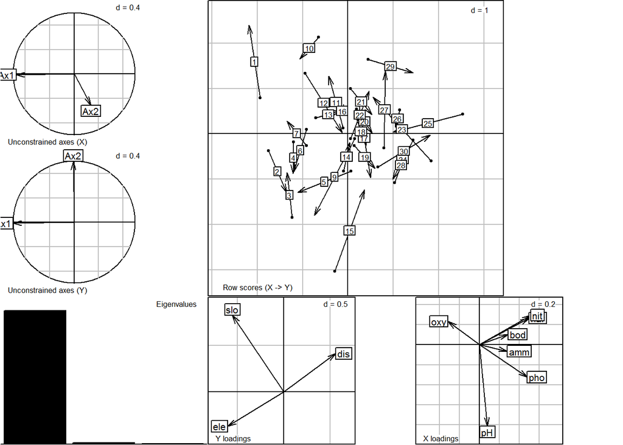

```r
plot(coia.chem.topo)
```

> RV coefficient 是总惯量除以两个数据表格单独排序的两个总惯量的积的平方根, 可视为 X 和 Y 的 Pearson 相关系数.

## 6.10 多因素分析(Multiple Factor Analysis, MFA)

### 6.10.1 简介

MFA 是另一种**对称分析**方法(基于两个以上的数据集), 该方法侧重的还是相关性分析, 不涉及对数据集中的任何因果推断的假设分析. 分析的数据变量必须属于相同的数据类型(要么是定量, 要么是定性). 如果所有的变量都是定量的, 那么 MFA 分析基本上就是应用于每一个自己加权的整组变量的主成分分析(PCA). **(注, 该处不要与 多元对应分析 multiple correspondence analysis, MCA 相混淆, MCA 分析中针对 单一矩阵中的定量变量进行分析)**.

MFA 分析步骤: -1> 对定量变量数据(中心化, 最适为标准化)进行 PCA 分析, -2> 重组已加权的数据, 将结果数据集进行 全局PCA 分析, -3> 将变量的不同子集投影到全局结果中, 评估对象和变量的共有结构和差异.

计算: ade4 工具包中的 mfa() 函数, 或者 FactoMineR 工具包中的 MFA() *(该方法的优点更多)*.

MFA的分析方法可以扩展到层次数据结构中, 进而形成等级多因素分析(Hierarchical Multiple Factor Analysis, HMFA), 可用于探索高山森林生态系统中植被+土壤+动物+腐殖质之间的结构关系. HMFA 的原理是变量最低级层次开始计算每一个级别的MFA, 计算结果被更高一级的层次计算所使用, 其中根据组的数量进行新的加权. 可使用 FactoMineR 工具包中的 HMFA() 进行相应的计算.

### 6.10.2 使用 FactoMineR 分析包进行多因素分析(MFA)

```r
# 对变量的 3 个分组进行多因素分
# 重新整合 3 个表 (Hellinger-transformed species, physiographic variables, chemical variables) - 物种 & 地形变量 & 化学变量
tab3 <- data.frame(spe.hel, envtopo, envchem)
dim(tab3)
```

```
## [1] 29 37
```

```r
# 每个分组中的变量数量
(grn <- c(ncol(spe), ncol(envtopo), ncol(envchem)))
```

```
## [1] 27  3  7
```

```r
# 关闭之前的图形窗口
graphics.off()
# 多因素分析计算, 绘制图形
# MFA 多因素分析
# https://www.rdocumentation.org/packages/FactoMineR/versions/1.41/topics/MFA
(t3.mfa <- MFA(
 tab3,
 group = grn,
 type = c("c", "s", "s"),
 ncp = 2,
 name.group = c("Fish community", "Physiography", "Water quality"),
 graph = T
 ))
```

```
## **Results of the Multiple Factor Analysis (MFA)**
## The analysis was performed on 29 individuals, described by 37 variables
## *Results are available in the following objects :
##
##   name                 description
## 1 "$eig"               "eigenvalues"
## 2 "$separate.analyses" "separate analyses for each group of variables"
## 3 "$group"             "results for all the groups"
## 4 "$partial.axes"      "results for the partial axes"
## 5 "$inertia.ratio"     "inertia ratio"
## 6 "$ind"               "results for the individuals"
## 7 "$quanti.var"        "results for the quantitative variables"
## 8 "$summary.quanti"    "summary for the quantitative variables"
## 9 "$global.pca"        "results for the global PCA"
```

```r
# 多因素分析计算, 不绘制图形
(t3.mfa <- MFA(
 tab3,
 group = grn,
 type = c("c", "s", "s"),
 ncp = 2,
 name.group = c("Fish community", "Physiography", "Water quality"),
 graph = FALSE
 ))
```

```
## **Results of the Multiple Factor Analysis (MFA)**
## The analysis was performed on 29 individuals, described by 37 variables
## *Results are available in the following objects :
##
##   name                 description
## 1 "$eig"               "eigenvalues"
## 2 "$separate.analyses" "separate analyses for each group of variables"
## 3 "$group"             "results for all the groups"
## 4 "$partial.axes"      "results for the partial axes"
## 5 "$inertia.ratio"     "inertia ratio"
## 6 "$ind"               "results for the individuals"
## 7 "$quanti.var"        "results for the quantitative variables"
## 8 "$summary.quanti"    "summary for the quantitative variables"
## 9 "$global.pca"        "results for the global PCA"
```

```r
summary(t3.mfa)
```

```
##
## Call:
## MFA(base = tab3, group = grn, type = c("c", "s", "s"), ncp = 2,
##      name.group = c("Fish community", "Physiography", "Water quality"),
##      graph = FALSE)
##
##
## Eigenvalues
##                        Dim.1   Dim.2   Dim.3   Dim.4   Dim.5   Dim.6
## Variance               2.341   0.773   0.513   0.377   0.201   0.154
## % of var.             47.704  15.744  10.464   7.690   4.090   3.133
## Cumulative % of var.  47.704  63.448  73.913  81.602  85.692  88.825
##                        Dim.7   Dim.8   Dim.9  Dim.10  Dim.11  Dim.12
## Variance               0.134   0.108   0.057   0.047   0.041   0.030
## % of var.              2.724   2.192   1.160   0.961   0.839   0.615
## Cumulative % of var.  91.549  93.740  94.900  95.860  96.700  97.315
##                       Dim.13  Dim.14  Dim.15  Dim.16  Dim.17  Dim.18
## Variance               0.028   0.020   0.019   0.015   0.012   0.009
## % of var.              0.568   0.409   0.385   0.310   0.244   0.190
## Cumulative % of var.  97.883  98.292  98.678  98.987  99.232  99.422
##                       Dim.19  Dim.20  Dim.21  Dim.22  Dim.23  Dim.24
## Variance               0.007   0.006   0.005   0.003   0.003   0.002
## % of var.              0.140   0.123   0.112   0.067   0.056   0.033
## Cumulative % of var.  99.561  99.684  99.796  99.863  99.919  99.952
##                       Dim.25  Dim.26  Dim.27  Dim.28
## Variance               0.001   0.001   0.000   0.000
## % of var.              0.023   0.015   0.008   0.002
## Cumulative % of var.  99.975  99.990  99.998 100.000
##
## Groups
##                   Dim.1    ctr   cos2    Dim.2    ctr   cos2
## Fish community |  0.842 35.965  0.624 |  0.202 26.193  0.036 |
## Physiography   |  0.798 34.075  0.570 |  0.163 21.130  0.024 |
## Water quality  |  0.701 29.961  0.448 |  0.407 52.676  0.151 |
##
## Individuals (the 10 first)
##                   Dim.1    ctr   cos2    Dim.2    ctr   cos2
## 1              | -2.892 12.318  0.401 | -1.686 12.695  0.136 |
## 2              | -2.268  7.579  0.749 | -0.467  0.973  0.032 |
## 3              | -2.095  6.463  0.717 | -0.282  0.354  0.013 |
## 4              | -1.710  4.309  0.722 | -0.046  0.009  0.001 |
## 5              | -0.730  0.784  0.157 | -0.538  1.294  0.086 |
## 6              | -1.478  3.219  0.580 | -0.424  0.801  0.048 |
## 7              | -1.831  4.941  0.811 | -0.138  0.085  0.005 |
## 9              | -0.543  0.435  0.079 | -0.571  1.457  0.087 |
## 10             | -1.182  2.057  0.392 | -0.368  0.605  0.038 |
## 11             | -0.990  1.444  0.361 |  0.316  0.446  0.037 |
##
## Continuous variables (the 10 first)
##                   Dim.1    ctr   cos2    Dim.2    ctr   cos2
## Cogo           | -0.032  0.179  0.068 |  0.051  1.341  0.167 |
## Satr           | -0.233  9.334  0.788 | -0.030  0.468  0.013 |
## Phph           | -0.167  4.794  0.607 |  0.042  0.904  0.038 |
## Babl           | -0.138  3.253  0.548 |  0.041  0.865  0.048 |
## Thth           | -0.029  0.143  0.051 |  0.052  1.388  0.163 |
## Teso           | -0.012  0.024  0.009 |  0.056  1.624  0.212 |
## Chna           |  0.054  0.493  0.386 |  0.028  0.401  0.103 |
## Pato           |  0.039  0.259  0.133 |  0.055  1.555  0.264 |
## Lele           |  0.033  0.185  0.065 |  0.020  0.204  0.023 |
## Sqce           |  0.047  0.377  0.128 | -0.032  0.524  0.059 |
```

```r
t3.mfa$ind
```

```
## $coord
##         Dim.1       Dim.2
## 1  -2.8915941 -1.68640856
## 2  -2.2681196 -0.46678264
## 3  -2.0945790 -0.28177541
## 4  -1.7102638 -0.04574322
## 5  -0.7295912 -0.53840862
## 6  -1.4781978 -0.42369045
## 7  -1.8313882 -0.13765964
## 9  -0.5431187 -0.57137791
## 10 -1.1817234 -0.36811583
## 11 -0.9899563  0.31603938
## 12 -1.1739409  0.39362262
## 13 -1.0900124  0.70300214
## 14 -0.7477263  0.75428351
## 15 -0.6510034  0.93919350
## 16 -0.2533240  0.57014836
## 17  0.2994011  0.57860852
## 18  0.4038674  0.61755897
## 19  0.6052344  0.61148013
## 20  0.9097159  0.49294358
## 21  0.9455062  0.49548517
## 22  0.9791572  0.59345872
## 23  1.9837979 -1.90877037
## 24  1.7978543 -1.04709687
## 25  2.9956381 -2.51066348
## 26  1.8202250 -0.15651085
## 27  1.5661790  0.33203586
## 28  1.7314808  0.58726700
## 29  1.6682474  1.04806204
## 30  1.9282342  1.10981432
##
## $contrib
##          Dim.1        Dim.2
## 1  12.31772658 12.694855053
## 2   7.57857949  0.972593892
## 3   6.46322664  0.354411929
## 4   4.30905581  0.009340188
## 5   0.78417870  1.293975818
## 6   3.21900030  0.801308029
```

[output cut: 252 more lines]

```
## 26.Fish community 2.198706e-01 2.095774e-01
## 26.Physiography   6.770833e-02 1.591170e+00
## 26.Water quality  4.355375e-02 2.955690e+00
## 27.Fish community 6.484344e-01 3.704964e-02
## 27.Physiography   1.165384e-02 6.011855e-01
## 27.Water quality  8.339474e-01 9.367227e-01
## 28.Fish community 3.430590e-01 5.633142e-04
## 28.Physiography   4.128069e-02 5.092639e-01
## 28.Water quality  6.223457e-01 4.759524e-01
## 29.Fish community 2.993276e-03 4.098377e-02
## 29.Physiography   3.170415e+00 9.388838e-01
## 29.Water quality  3.368241e+00 5.875463e-01
## 30.Fish community 1.826553e-01 1.786017e-01
## 30.Physiography   2.468353e+00 9.861657e-01
## 30.Water quality  3.993927e+00 3.254084e-01
```

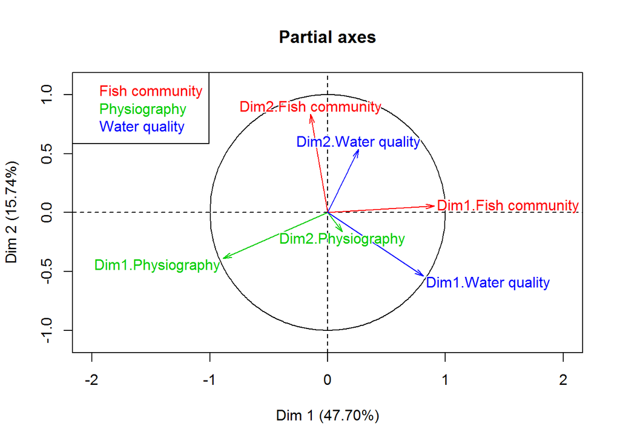

```r
plot(t3.mfa,
     choix = "axes",
     habillage = "group",
     shadowtext = TRUE)
```

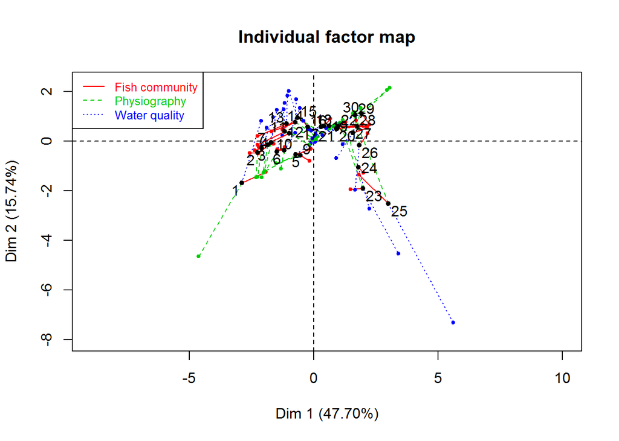

```r
plot(
  t3.mfa,
  choix = "ind",
  partial = "all",
  habillage = "group")
```

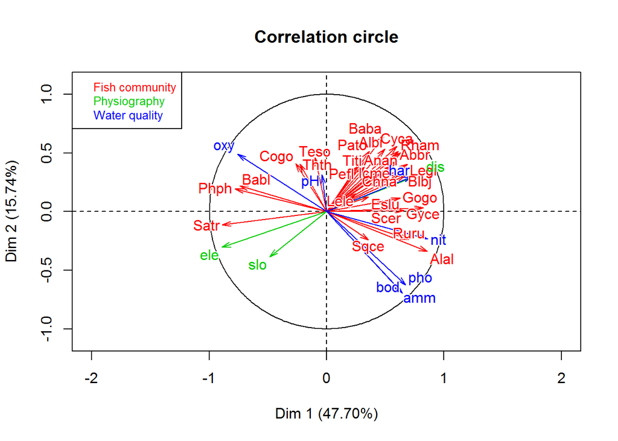

```r
plot(t3.mfa,
     choix = "var",
     habillage = "group",
     shadowtext = TRUE)
```

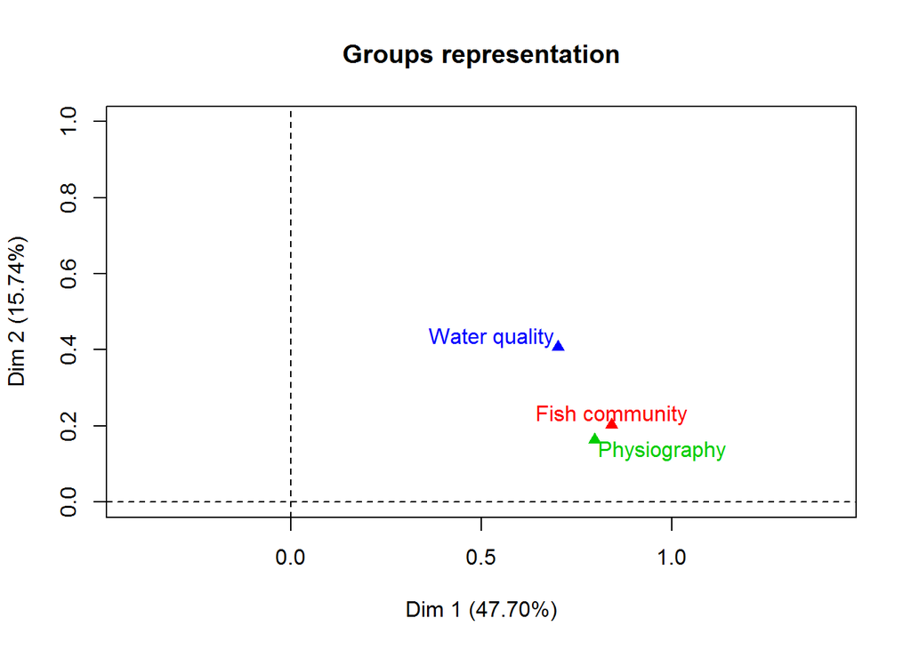

```r
plot(t3.mfa, choix = "group")
```

```r
# RV coefficients with tests (p-values above the diagonal of
# the matrix)
rvp <- t3.mfa$group$RV
rvp[1, 2] <- coeffRV(spe.hel, scale(envtopo))$p.value
rvp[1, 3] <- coeffRV(spe.hel, scale(envchem))$p.value
rvp[2, 3] <- coeffRV(scale(envtopo), scale(envchem))$p.value
round(rvp[-4, -4], 6)
```

```
##                Fish community Physiography Water quality
## Fish community       1.000000     0.000002      0.000002
## Physiography         0.580271     1.000000      0.002809
## Water quality        0.505324     0.361901      1.000000
```

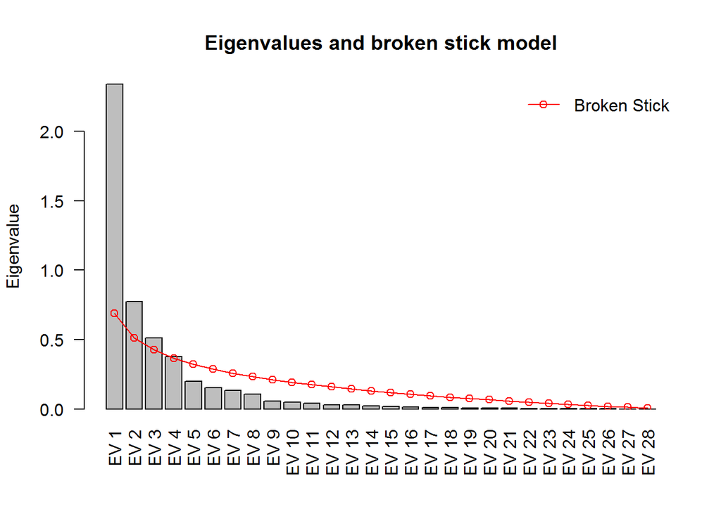

```r
# 特征值, 碎石图和破碎棒模型 - Eigenvalues, scree plot and broken stick model
ev <- t3.mfa$eig[, 1]
names(ev) <- paste("MFA", 1 : length(ev))
# ?screestick
screestick(ev,
           las = 2)
```

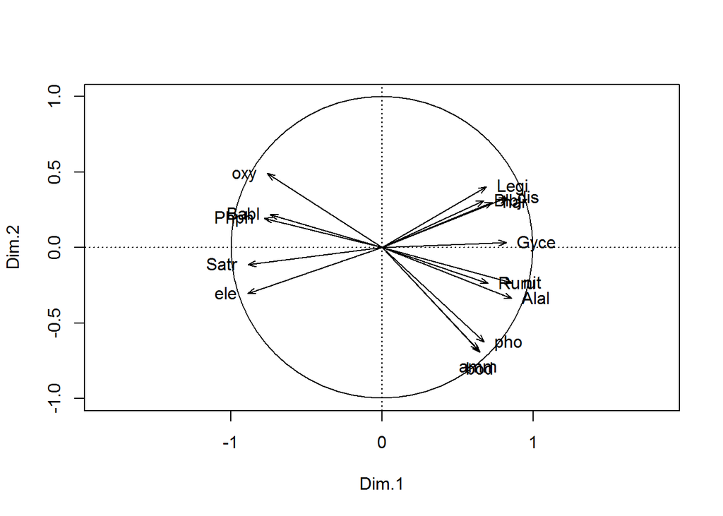

```r
# 替代性绘图
# 只绘制显著的变量 (相关性)
# 选择最特征的的变量
aa <- dimdesc(t3.mfa,
              axes = 1:2,
              proba = 0.0001)
# 绘图
varsig <-
  t3.mfa$quanti.var$cor[unique(c(rownames(aa$Dim.1$quanti),
              rownames(aa$Dim.2$quanti))), ]
plot(varsig[, 1:2],
  asp = 1,
  type = "n",
  xlim = c(-1, 1),
  ylim = c(-1, 1)
  )
abline(h = 0,
       lty = 3)
abline(v = 0,
       lty = 3)
symbols(0,
        0,
        circles = 1,
        inches = FALSE,
        add = TRUE)
arrows(0,
       0,
       varsig[, 1],
       varsig[, 2],
       length = 0.08,
       angle = 20)

for (v in 1 : nrow(varsig)) {
  if (abs(varsig[v, 1]) > abs(varsig[v, 2])) {
    if (varsig[v, 1] >=  0)
      pos <- 4
    else
      pos <- 2
    }
  else {
    if (varsig[v, 2] >=  0)
      pos <- 3
    else
      pos <- 1
    }
  text(varsig[v, 1],
       varsig[v, 2],
       labels = rownames(varsig)[v],
       pos = pos)
  }
```

## 6.11 关联物种特征和环境

生态位理论会预测已适应 环境的定植的 物种的生态和行为特征. 功能生态学主要研究物种特征和环境之间的相互关系. 这种研究方法, 由于要检验假设, 因此面临方法学上的挑战, 必须通过适合的方法评估物种特征与环境特征之间的关系, 如物种的有无或丰度所导致的群落结构特征与环境之间的相互关系.

下文将介绍两种解决上述问题的方法: -1> RLQ, -2> fourth-corner methods. 这两种方法具有互补的特性: RLQ 是一种排序方法, 允许三种数据表组合的数据结构的可视化, 但只是一种简单的全局检验; fourth-corner methods 是一系列个体特征与环境相互关系的统计检验, 不考虑个体特征与环境变量之间的协方差, 同时没有关于位点和物种的输出结果.

本书中介绍了一些提高两种方法互补性的调整: 整体数据由三种矩阵组成, -1> 矩阵A(或者矩阵L) – 物种有无或者丰度数据 (n 个位点, p 个物种) , -2> 矩阵B(或者矩阵Q) – 生物学或者行为特征数据 (p 个物种, s 个生物学特征或者行为特征), -3> 矩阵C(或者矩阵R) – 栖息地特征数据 (n 个位点, m 个栖息地特征).

> 主要目的是为了研究物种特征和环境之间的相互关系.

RLQ 方法是分析由矩阵L连接起来的矩阵R和矩阵Q (矩阵L在此处起到了链接作用), s*m 矩阵的交叉特征和环境变量 是第四个矩阵(也成为 矩阵D, 第四角)

### 6.11.1 四角法分析(The Fourth-Corner Method)

该方法的原理在于: -1> 估计矩阵D的参数, -2> 检验参数的显著性(差异性), 在六种置换模型中选择最适合的一种.

Model 1: environmental control over individual species. Model 2: environmental control over species assemblages. Model 3: lottery. Model 4: random species attributes. Model 5: permute rows and columns. Model 6: this is actually a combination of models 2 and 4.

### 6.11.2 物种功能属性与环境因子关系分析( RLQ Analysis)

RLQ 分析方法是共惯量(co-inertia analysis, CoIA)分析的一个扩展.

### 6.11.3 在 R 中的应用

该部分数据的科研背景: 阿尔卑斯山上的植物性状对积雪融化梯度的响应. 主要的科学问题是: 根据植物物种的功能特征评估, 积雪的持续时间及其所有后果如何影响高山草原?

> 结果图的解读是**重点!!!**

```r
data(aravo)
dim(aravo$spe)
```

```
## [1] 75 82
```

```r
dim(aravo$traits)
```

```
## [1] 82  8
```

```r
dim(aravo$env)
```

```
## [1] 75  6
```

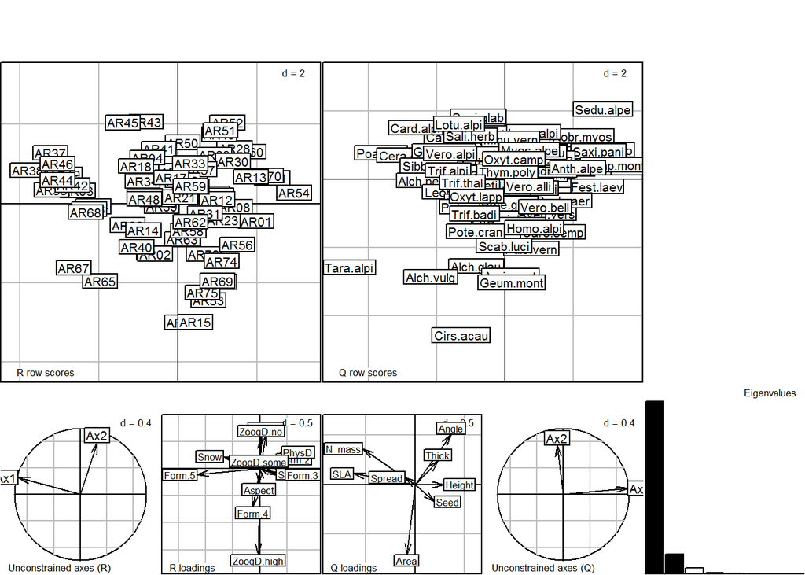

```r
# 初步分析: CA, Hill-Smith and PCA
afcL.aravo <- dudi.coa(aravo$spe, scannf = FALSE)
acpR.aravo <- dudi.hillsmith(aravo$env,
                 row.w = afcL.aravo$lw,
                 scannf = FALSE)
acpQ.aravo <- dudi.pca(aravo$traits,
                 row.w = afcL.aravo$cw,
                 scannf = FALSE)

# RLQ analysis
rlq.aravo <- rlq(
                 dudiR = acpR.aravo,
                 dudiL = afcL.aravo,
                 dudiQ = acpQ.aravo,
                 scannf = FALSE)
plot(rlq.aravo)
```

```r
# Traits by environment crossed table
rlq.aravo$tab
```

```
##                  Height       Spread       Angle         Area       Thick
## Aspect     -0.045735104 -0.044170141 -0.09083720  0.031237858 -0.05846614
## Slope       0.094917344 -0.017325425  0.10028197 -0.003864605  0.07415182
## Form.1     -0.073770286  0.026039390  0.14215018 -0.225313466  0.11572805
## Form.2     -0.010911331 -0.100446093  0.16807508 -0.120331757  0.03864688
## Form.3      0.233960654 -0.068975646  0.18296508  0.012061050  0.13483093
## Form.4     -0.086529686 -0.058073850 -0.23974216  0.142160619 -0.15198206
## Form.5     -0.252340378  0.220918447 -0.43798612  0.247700338 -0.30735550
## PhysD       0.113164322 -0.051680330  0.22138008 -0.134371361  0.14316173
## ZoogD.no    0.124267509  0.012175895  0.15202700 -0.137974965  0.03391263
## ZoogD.some -0.149543344 -0.008373275 -0.03745347 -0.051242752  0.01221228
## ZoogD.high  0.006993334 -0.013438166 -0.31869900  0.480953816 -0.11735229
## Snow       -0.271739531  0.065634673 -0.26961376 -0.024574466 -0.15466014
##                     SLA       N_mass        Seed
## Aspect     -0.007694551 -0.061575524  0.01159843
## Slope      -0.235864886 -0.201308154  0.07707397
## Form.1     -0.085532690  0.003024247  0.02201012
## Form.2     -0.246531063 -0.225091274 -0.02010957
## Form.3     -0.328895353 -0.290591512  0.09090024
## Form.4      0.043829953 -0.044209280  0.02986325
## Form.5      0.887669867  0.755913589 -0.22660391
## PhysD      -0.275524984 -0.212434381  0.07815631
## ZoogD.no    0.034928046  0.099790495 -0.02157176
## ZoogD.some -0.024512275 -0.037432290 -0.03230914
## ZoogD.high -0.037441256 -0.180296100  0.12984602
## Snow        0.481181824  0.429271163 -0.17764072
```

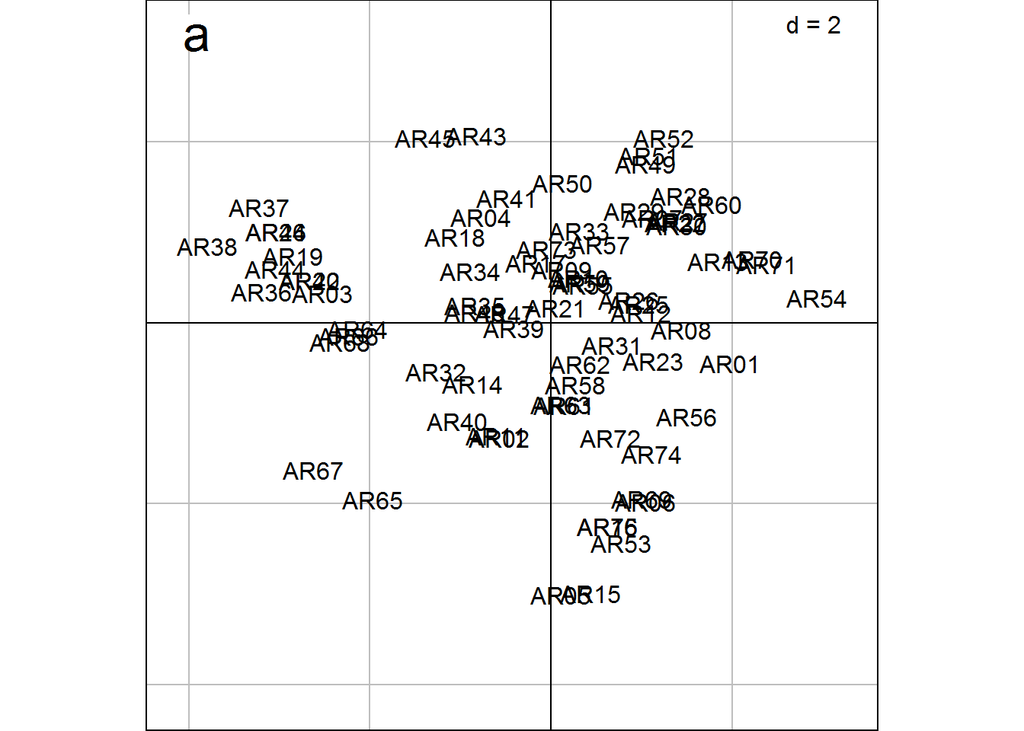

```r
# 单一绘图拥挤, 逐个绘制
s.label(rlq.aravo$lR,
  plabels.boxes.draw = FALSE,
  ppoints.alpha = 0,
  psub.text = "a",
  psub.cex = 2,
  psub.position = "topleft"
  )
```

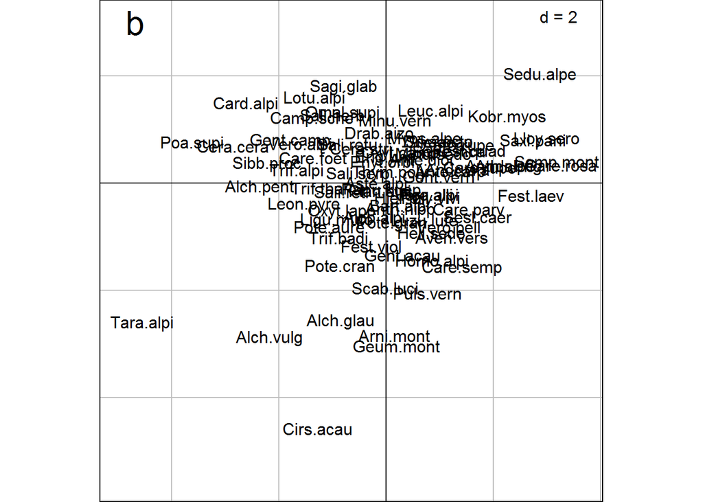

```r
s.label(rlq.aravo$lQ,
  plabels.boxes.draw = FALSE,
  ppoints.alpha = 0,
  psub.text = "b",
  psub.cex = 2,
  psub.position = "topleft"
  )
```

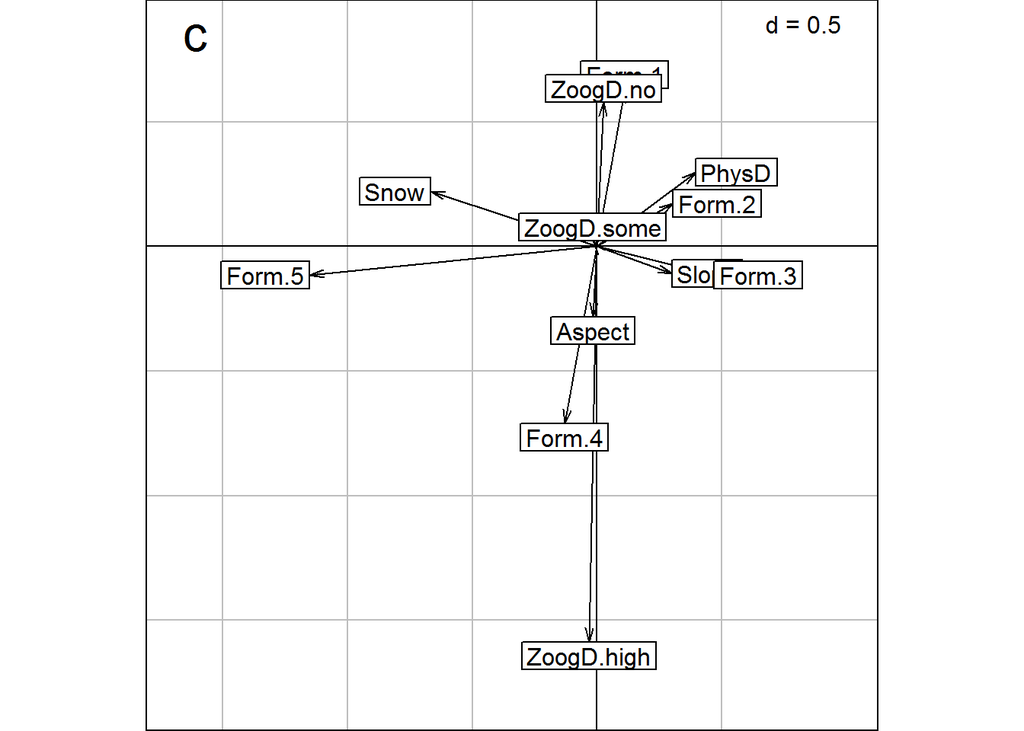

```r
s.arrow(rlq.aravo$l1,
  psub.text = "c",
  psub.cex = 2,
  psub.position = "topleft"
  )
```

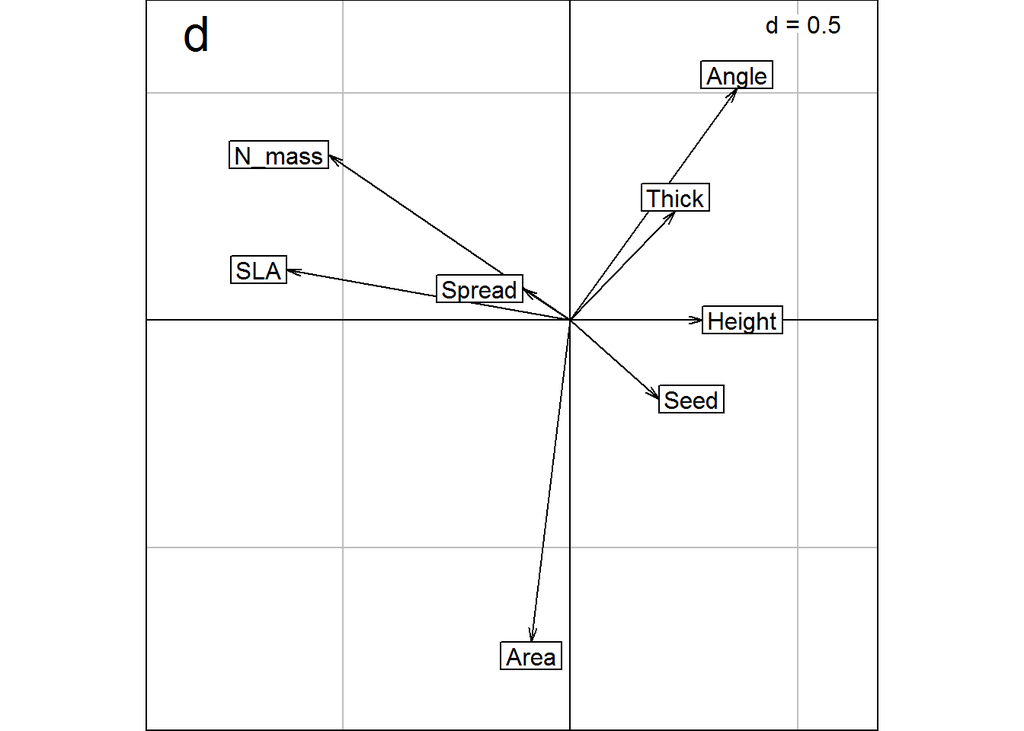

```r
s.arrow(rlq.aravo$c1,
  psub.text = "d",
  psub.cex = 2,
  psub.position = "topleft"
  )
```

```r
# 全局检验 - Global test
# 置换检验的类
# https://www.rdocumentation.org/packages/ade4/versions/1.7-13/topics/randtest
randtest(rlq.aravo,
         nrepet = 999,
         modeltype = 6)
```

```
## class: krandtest lightkrandtest
## Monte-Carlo tests
## Call: randtest.rlq(xtest = rlq.aravo, nrepet = 999, modeltype = 6)
##
## Number of tests:   2
##
## Adjustment method for multiple comparisons:   none
## Permutation number:   999
##      Test     Obs  Std.Obs   Alter Pvalue
## 1 Model 2 1.57836 29.28393 greater  0.001
## 2 Model 4 1.57836 13.30195 greater  0.001
```

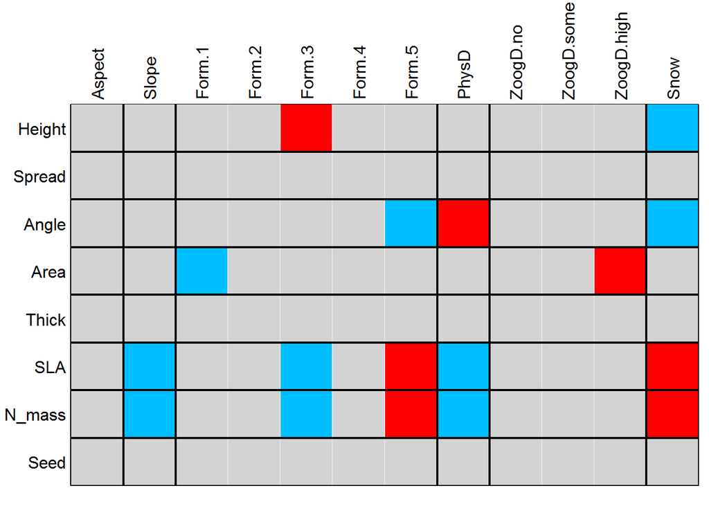

```r
# 四象限分析方法 - Fourth-corner analysis
fourth.aravo <- fourthcorner(
                      tabR = aravo$env,
                      tabL = aravo$spe,
                      tabQ = aravo$traits,
                      modeltype = 6,
                      p.adjust.method.G = "none",
                      p.adjust.method.D = "none",
                      nrepet = 999)
# 使用 FDR 进行多重检验校正
fourth.aravo.adj <- p.adjust.4thcorner(
                      fourth.aravo,
                      p.adjust.method.G = "fdr",
                      p.adjust.method.D = "fdr",
                      p.adjust.D = "global")
# 绘制显著性关联
plot(fourth.aravo.adj,
     alpha = 0.05,
     stat = "D2")
```

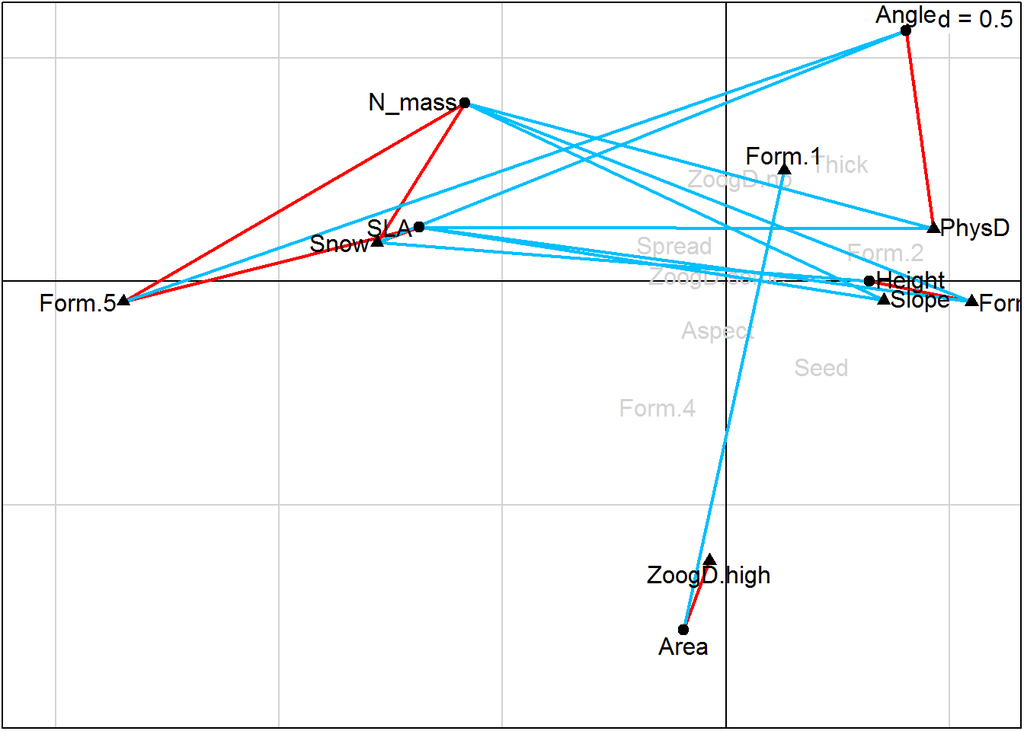

```r
# Biplot combining RLQ and fourth-corner results
plot(fourth.aravo.adj,
  x.rlq = rlq.aravo,
  alpha = 0.05,
  stat = "D2",
  type = "biplot"
  )
```

```r
summary(fishtraits)
```

```
##       sort                        LatinName            Family
##  Min.   : 1.0   Abramis brama          : 1   Cyprinidae   :17
##  1st Qu.: 7.5   Alburnoides bipunctatus: 1   Percidae     : 2
##  Median :14.0   Alburnus alburnus      : 1   Salmonidae   : 2
##  Mean   :14.0   Ameiurus melas         : 1   Anguillidae  : 1
##  3rd Qu.:20.5   Anguilla anguilla      : 1   Centrarchidae: 1
##  Max.   :27.0   Barbatula barbatula    : 1   Cottidae     : 1
##                 (Other)                :21   (Other)      : 3
##          EnglishName              FrenchName   BodyLength
##  Barbel        : 1   Ablette           : 1   Min.   : 40.0
##  Black bullhead: 1   Anguille          : 1   1st Qu.: 85.0
##  Bleak         : 1   Barbeau fluviatile: 1   Median :180.0
##  Brown trout   : 1   Blageon           : 1   Mean   :196.7
##  Bullhead      : 1   Bouvi\350re          : 1   3rd Qu.:270.0
##  Common carp   : 1   Br\350me bordeli\350re  : 1   Max.   :600.0
##  (Other)       :21   (Other)           :21
##  BodyLengthMax     ShapeFactor      TrophicLevel      omnivory
##  Min.   :  70.0   Min.   : 2.410   Min.   :2.000   Min.   :0.0000
##  1st Qu.: 150.0   1st Qu.: 3.265   1st Qu.:2.845   1st Qu.:0.0000
##  Median : 360.0   Median : 4.330   Median :3.100   Median :1.0000
##  Mean   : 388.1   Mean   : 4.624   Mean   :3.166   Mean   :0.7037
##  3rd Qu.: 530.0   3rd Qu.: 5.015   3rd Qu.:3.495   3rd Qu.:1.0000
##  Max.   :1100.0   Max.   :16.670   Max.   :5.000   Max.   :1.0000
##
##   detritivory        herbivory       invertivory       piscivory
##  Min.   :0.00000   Min.   :0.0000   Min.   :0.0000   Min.   :0.0000
##  1st Qu.:0.00000   1st Qu.:0.0000   1st Qu.:1.0000   1st Qu.:0.0000
##  Median :0.00000   Median :0.0000   Median :1.0000   Median :0.0000
##  Mean   :0.03704   Mean   :0.2222   Mean   :0.9259   Mean   :0.2222
##  3rd Qu.:0.00000   3rd Qu.:0.0000   3rd Qu.:1.0000   3rd Qu.:0.0000
##  Max.   :1.00000   Max.   :1.0000   Max.   :1.0000   Max.   :1.0000
##
##    carnivory
##  Min.   :0.00000
##  1st Qu.:0.00000
##  Median :0.00000
##  Mean   :0.03704
##  3rd Qu.:0.00000
##  Max.   :1.00000
##
```

```r
rownames(fishtraits)
```

```
##  [1] "Cogo" "Satr" "Phph" "Babl" "Thth" "Teso" "Chna" "Pato" "Lele" "Sqce"
## [11] "Baba" "Albi" "Gogo" "Eslu" "Pefl" "Rham" "Legi" "Scer" "Cyca" "Titi"
## [21] "Abbr" "Icme" "Gyce" "Ruru" "Blbj" "Alal" "Anan"
```

```r
names(spe)
```

```
##  [1] "Cogo" "Satr" "Phph" "Babl" "Thth" "Teso" "Chna" "Pato" "Lele" "Sqce"
## [11] "Baba" "Albi" "Gogo" "Eslu" "Pefl" "Rham" "Legi" "Scer" "Cyca" "Titi"
## [21] "Abbr" "Icme" "Gyce" "Ruru" "Blbj" "Alal" "Anan"
```

```r
names(fishtraits)
```

```
##  [1] "sort"          "LatinName"     "Family"        "EnglishName"
##  [5] "FrenchName"    "BodyLength"    "BodyLengthMax" "ShapeFactor"
##  [9] "TrophicLevel"  "omnivory"      "detritivory"   "herbivory"
## [13] "invertivory"   "piscivory"     "carnivory"
```

```r
(tra <- fishtraits[ , 6:15])
```

```
##      BodyLength BodyLengthMax ShapeFactor TrophicLevel omnivory
## Cogo         80           120        3.13         3.10        0
## Satr        280           800        5.03         4.00        0
## Phph         60           100        2.95         3.10        1
## Babl         80           130        4.50         3.10        1
## Thth        300           450        4.33         3.10        0
## Teso         90           180        5.26         3.40        1
## Chna        280           480        6.50         2.00        1
## Pato        160           250        5.00         2.00        1
## Lele        180           360        2.81         2.57        1
## Sqce        240           500        3.97         3.50        1
## Baba        300           600        4.38         3.10        0
## Albi         80           110        4.21         2.90        1
## Gogo         90           130        4.00         3.10        0
## Eslu        600          1100        5.23         5.00        0
## Pefl        200           400        4.92         4.35        1
## Rham         40            70        2.68         2.50        1
## Legi         80           160        3.23         4.00        1
## Scer        180           400        3.58         2.50        1
## Cyca        360           800        2.71         2.40        1
## Titi        260           560        4.43         3.49        1
## Abbr        240           600        5.20         2.94        1
## Icme        180           280        5.83         3.70        1
## Gyce         80           150        3.64         3.10        0
## Ruru        200           400        4.95         2.79        1
## Blbj        160           360        3.30         3.10        1
## Alal         90           150        2.41         3.10        0
## Anan        420           840       16.67         3.53        1
##      detritivory herbivory invertivory piscivory carnivory
## Cogo           0         0           1         0         0
## Satr           0         0           1         1         0
## Phph           0         0           1         0         0
## Babl           0         0           1         0         0
## Thth           0         0           1         0         0
## Teso           0         0           1         0         0
## Chna           0         1           0         0         0
## Pato           0         1           0         0         0
## Lele           0         0           1         0         0
## Sqce           0         0           1         1         0
## Baba           0         0           1         0         0
## Albi           0         0           1         0         0
## Gogo           0         0           1         0         0
## Eslu           0         0           1         0         1
## Pefl           0         0           1         1         0
## Rham           0         1           1         0         0
## Legi           0         0           1         1         0
## Scer           0         1           1         0         0
## Cyca           0         0           1         0         0
## Titi           0         0           1         0         0
## Abbr           0         1           1         0         0
## Icme           0         0           1         1         0
## Gyce           0         0           1         0         0
## Ruru           0         1           1         0         0
## Blbj           1         0           1         0         0
## Alal           0         0           1         0         0
## Anan           0         0           1         1         0
```

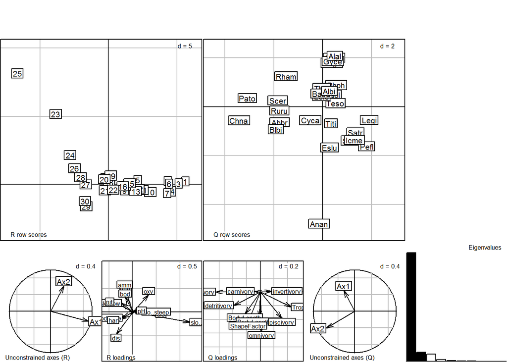

```r
# 初步分析: CA, Hill-Smith and PCA
afcL.doubs <- dudi.coa(spe, scannf = FALSE)
acpR.doubs <- dudi.hillsmith(env3,
                             row.w = afcL.doubs$lw,
                             scannf = FALSE)
acpQ.doubs <- dudi.pca(tra,
                       row.w = afcL.doubs$cw,
                       scannf = FALSE)

# RLQ analysis
rlq.doubs <- rlq(
  dudiR = acpR.doubs,
  dudiL = afcL.doubs,
  dudiQ = acpQ.doubs,
  scannf = FALSE)
plot(rlq.doubs)
```

```r
# 环境交叉表的特征 - Traits by environment crossed table
rlq.doubs$tab
```

```
##                   BodyLength BodyLengthMax  ShapeFactor TrophicLevel
## ele             -0.048304152   0.007187924 -0.060883144   0.14550504
## slo..low        -0.017490743  -0.042314385  0.028173876  -0.10332302
## slo..moderate    0.053468631   0.018452115  0.038660030  -0.03675022
## slo..steep       0.012764213   0.044472082 -0.058091318   0.06664037
## slo..very_steep -0.150829448  -0.003810391 -0.120825431   0.35641751
## dis              0.075930870   0.038768449  0.079306651  -0.06860211
## pH              -0.003432257   0.005395255  0.001410929   0.01523394
## har              0.049612219   0.003552883  0.047554395  -0.07812182
## pho              0.005694775  -0.020467209 -0.015984913  -0.04423123
## nit              0.031487709  -0.014055496  0.028000121  -0.12066480
## amm              0.003344447  -0.023053222 -0.026949586  -0.05270107
## oxy             -0.076554553  -0.041159524 -0.029157570   0.04854716
## bod              0.021633266  -0.003731298 -0.023495670  -0.02877153
##                     omnivory  detritivory   herbivory  invertivory
## ele              0.001220866 -0.112888313 -0.16764187  0.079355078
## slo..low         0.023676424  0.052083402  0.07775053 -0.022512149
## slo..moderate   -0.009246294  0.032606431  0.09158491 -0.032911262
## slo..steep      -0.020344186 -0.059911497 -0.07007388 -0.011378061
## slo..very_steep -0.010310077 -0.178494331 -0.45323783  0.214087210
## dis              0.015973267  0.107803023  0.13306982 -0.017243386
## pH              -0.019344190  0.007199329 -0.05014765  0.043460474
## har              0.014966630  0.074351018  0.10567155 -0.016653112
## pho             -0.063446562  0.032083700  0.06674035  0.021141933
## nit             -0.012001378  0.080520901  0.14049498 -0.060467950
## amm             -0.059129644  0.022353331  0.07448860 -0.003210997
## oxy             -0.025741778 -0.096639390 -0.15198220 -0.012422352
## bod             -0.054527460  0.041863723  0.07447643  0.026254593
##                    piscivory    carnivory
## ele              0.095114774  0.005006426
## slo..low        -0.061420402 -0.028901056
## slo..moderate   -0.034273657  0.026091937
## slo..steep       0.033165788  0.006058776
## slo..very_steep  0.267575043 -0.003195297
## dis             -0.027125102  0.022175494
## pH               0.001001406 -0.018157863
## har             -0.039871103  0.008731115
## pho             -0.051247522  0.025689821
## nit             -0.093464939  0.013011015
## amm             -0.056585254  0.027778781
## oxy              0.036126244 -0.058859660
## bod             -0.040833689  0.036767673
```

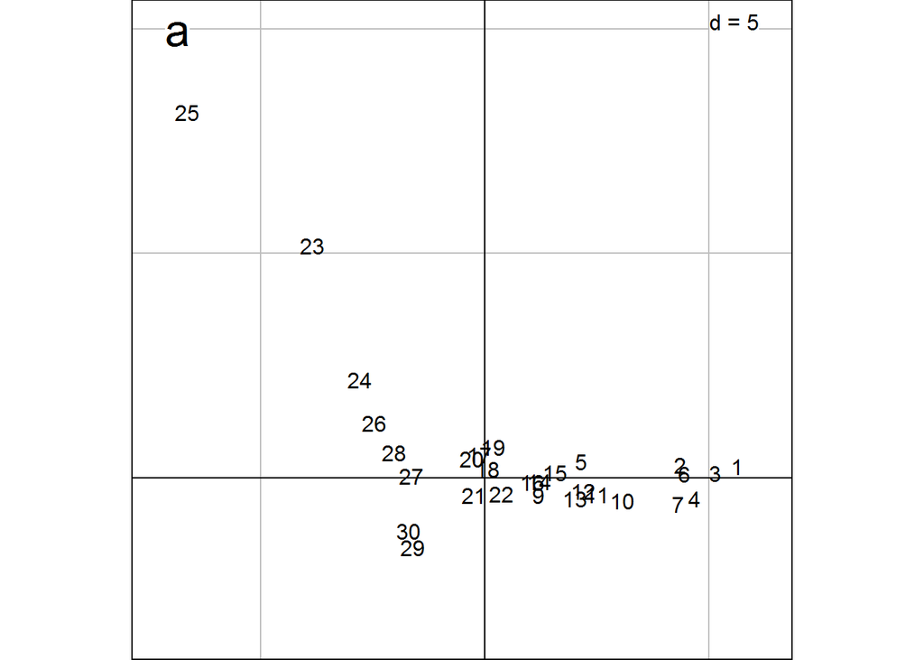

```r
# 单一绘图拥挤, 逐个绘制
s.label(rlq.doubs$lR,
        plabels.boxes.draw = FALSE,
        ppoints.alpha = 0,
        psub.text = "a",
        psub.cex = 2,
        psub.position = "topleft"
        )
```

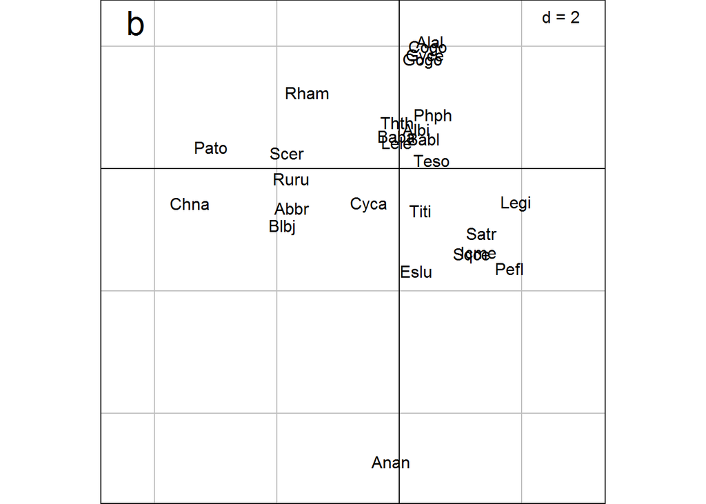

```r
s.label(rlq.doubs$lQ,
        plabels.boxes.draw = FALSE,
        ppoints.alpha = 0,
        psub.text = "b",
        psub.cex = 2,
        psub.position = "topleft"
        )
```

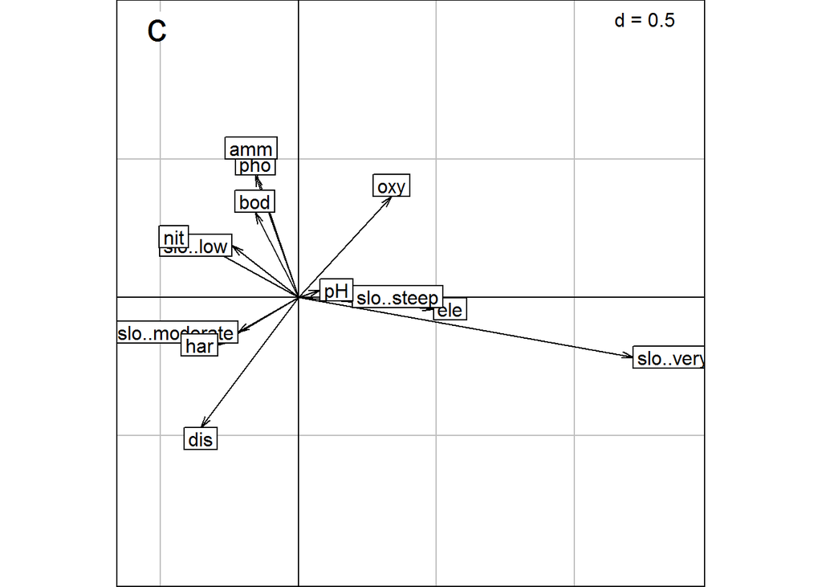

```r
s.arrow(rlq.doubs$l1,
        psub.text = "c",
        psub.cex = 2,
        psub.position = "topleft"
        )
```

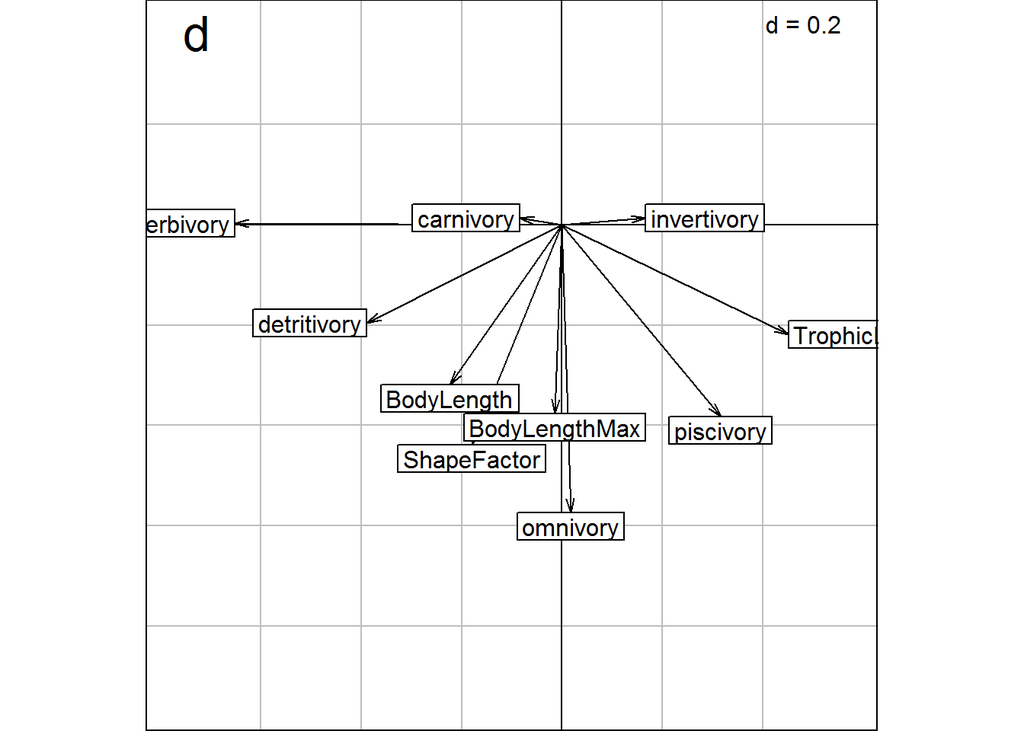

```r
s.arrow(rlq.doubs$c1,
        psub.text = "d",
        psub.cex = 2,
        psub.position = "topleft"
        )
```

```r
# 全局检测 - Global test
# randtest - 置换检验的类
# https://www.rdocumentation.org/packages/ade4/versions/1.7-13/topics/randtest
randtest(rlq.doubs,
         nrepet = 999,
         modeltype = 6)
```

```
## class: krandtest lightkrandtest
## Monte-Carlo tests
## Call: randtest.rlq(xtest = rlq.doubs, nrepet = 999, modeltype = 6)
##
## Number of tests:   2
##
## Adjustment method for multiple comparisons:   none
## Permutation number:   999
##      Test       Obs   Std.Obs   Alter Pvalue
## 1 Model 2 0.3945768  4.858889 greater  0.002
## 2 Model 4 0.3945768 -1.258504 greater  0.949
```

```r
# 四象限分析 - Fourth-corner analysis
# ?fourthcorner
# https://www.rdocumentation.org/packages/ade4/versions/1.7-13/topics/fourthcorner
# 对丰度数据或者二元'有-无'数据进行四象限分析
(fourth.doubs2 <- fourthcorner(
  tabR = env3,
  tabL = spe,
  tabQ = tra,
  modeltype = 2,
  p.adjust.method.G = "fdr",
  p.adjust.method.D = "fdr",
  nrepet = 4999 # 置换检验
  ))
```

```
## Fourth-corner Statistics
## ------------------------
## Permutation method  2  ( 4999  permutations)
##
## Adjustment method for multiple comparisons:   fdr
## call:  fourthcorner(tabR = env3, tabL = spe, tabQ = tra, modeltype = 2,      nrepet = 4999, p.adjust.method.G = "fdr", p.adjust.method.D = "fdr")
##
## ---
##
##                                Test   Stat          Obs     Std.Obs
## 1                  ele / BodyLength      r -0.048304152 -1.40313209
## 2             slo..low / BodyLength Homog.  0.334752165  0.85342779
## 3        slo..moderate / BodyLength Homog.  0.373622449  1.37784387
## 4           slo..steep / BodyLength Homog.  0.185317164 -0.33671311
## 5      slo..very_steep / BodyLength Homog.  0.102844708 -2.00723639
```

[output cut: 259 more lines]

```r
summary(fourth.doubs2)
```

```
## Fourth-corner Statistics
## ------------------------
## Permutation method  2  ( 4999  permutations)
##
## Adjustment method for multiple comparisons:   fdr
##                    Test Stat          Obs     Std.Obs     Alter Pvalue
## 1      ele / BodyLength    r -0.048304152 -1.40313209 two-sided 0.1652
## 2      slo / BodyLength    F  1.158517253 -0.01853857   greater 0.4196
## 3      dis / BodyLength    r  0.075930870  2.29988478 two-sided 0.0166
## 4       pH / BodyLength    r -0.003432257 -0.05661641 two-sided 0.9540
## 5      har / BodyLength    r  0.049612219  1.41775047 two-sided 0.1634
## 6      pho / BodyLength    r  0.005694775  0.30417316 two-sided 0.8100
## 7      nit / BodyLength    r  0.031487709  1.01081933 two-sided 0.3256
## 8      amm / BodyLength    r  0.003344447  0.24288001 two-sided 0.8522
## 9      oxy / BodyLength    r -0.076554553 -2.29647307 two-sided 0.0144
```

[output cut: 195 more lines]

```r
fourth.doubs <- fourthcorner(
  tabR = env2,
  tabL = spe,
  tabQ = tra,
  modeltype = 6,
  p.adjust.method.G = "none",
  p.adjust.method.D = "none",
  nrepet = 4999 # 置换检验
  )

# 使用 FDR 进行多重检验校正
(fourth.doubs.adj <- p.adjust.4thcorner(
  fourth.doubs,
  p.adjust.method.G = "fdr",
  p.adjust.method.D = "fdr",
  p.adjust.D = "global"))
```

```
## Fourth-corner Statistics
## ------------------------
## Permutation method  Comb. 2 and 4  ( 4999  permutations)
##
## Adjustment method for multiple comparisons:   fdr
## call:  fourthcorner(tabR = env2, tabL = spe, tabQ = tra, modeltype = 6,      nrepet = 4999, p.adjust.method.G = "none", p.adjust.method.D = "none")
##
## ---
##
##                    Test Stat          Obs      Std.Obs     Alter Pvalue
## 1      ele / BodyLength    r -0.048304152 -0.290842058 two-sided 0.7806
## 2      slo / BodyLength    r -0.002377844  0.018234245 two-sided 0.9868
## 3      dis / BodyLength    r  0.075930870  0.598976193 two-sided 0.5692
## 4       pH / BodyLength    r -0.003432257 -0.057435434 two-sided  0.958
## 5      har / BodyLength    r  0.049612219  0.430037893 two-sided  0.685
```

[output cut: 199 more lines]

```r
summary(fourth.doubs.adj)
```

```
## Fourth-corner Statistics
## ------------------------
## Permutation method  Comb. 2 and 4  ( 4999  permutations)
##
## Adjustment method for multiple comparisons:   fdr
##                    Test Stat          Obs      Std.Obs     Alter Pvalue
## 1      ele / BodyLength    r -0.048304152 -0.290842058 two-sided 0.7806
## 2      slo / BodyLength    r -0.002377844  0.018234245 two-sided 0.9868
## 3      dis / BodyLength    r  0.075930870  0.598976193 two-sided 0.5692
## 4       pH / BodyLength    r -0.003432257 -0.057435434 two-sided 0.9580
## 5      har / BodyLength    r  0.049612219  0.430037893 two-sided 0.6850
## 6      pho / BodyLength    r  0.005694775  0.047856613 two-sided 0.9632
## 7      nit / BodyLength    r  0.031487709  0.227423682 two-sided 0.8332
## 8      amm / BodyLength    r  0.003344447  0.024517260 two-sided 0.9842
## 9      oxy / BodyLength    r -0.076554553 -0.575095539 two-sided 0.5898
```

[output cut: 195 more lines]

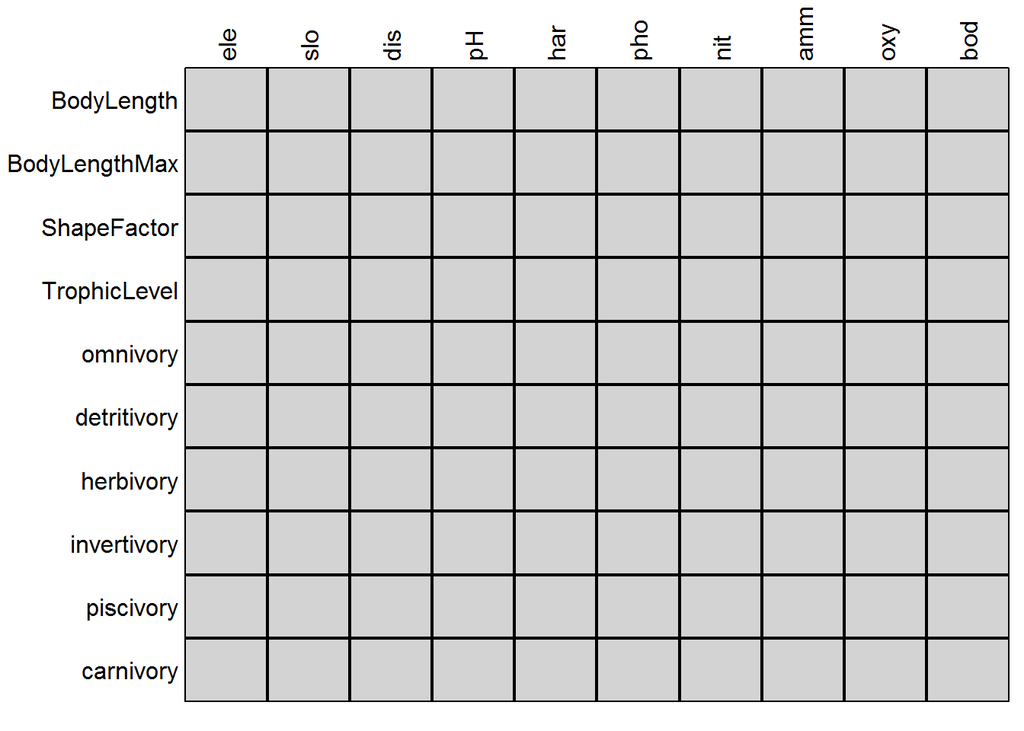

```r
plot(fourth.doubs.adj,
     alpha = 0.05,
     stat = "D2")
```

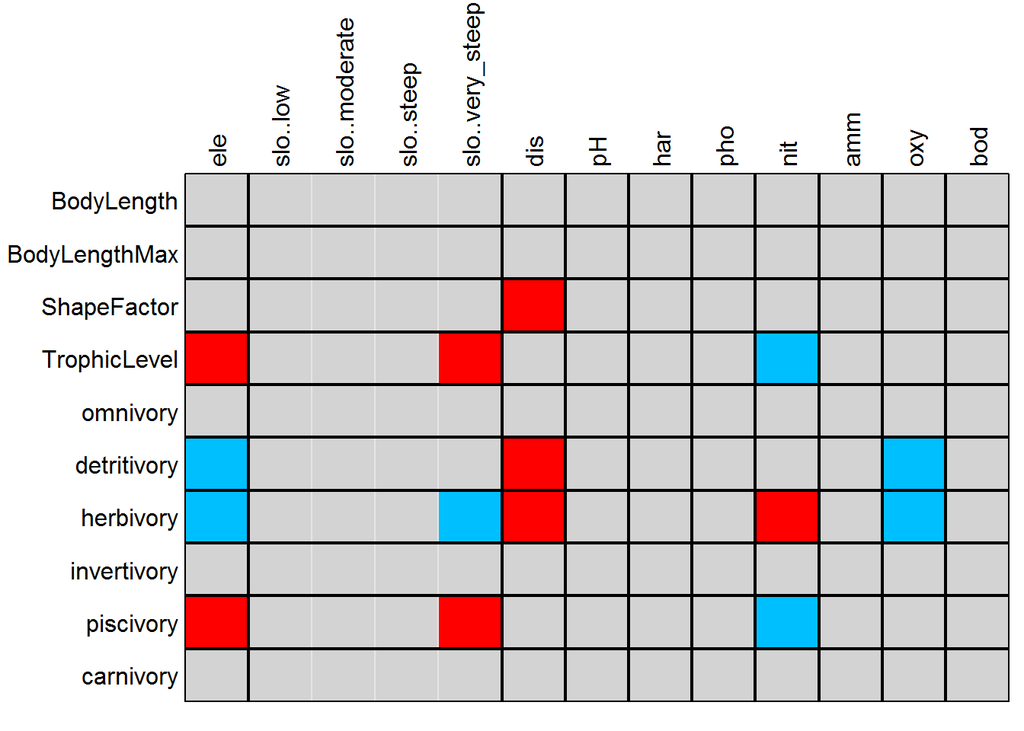

```r
plot(fourth.doubs2,
     stat = "D2")
```

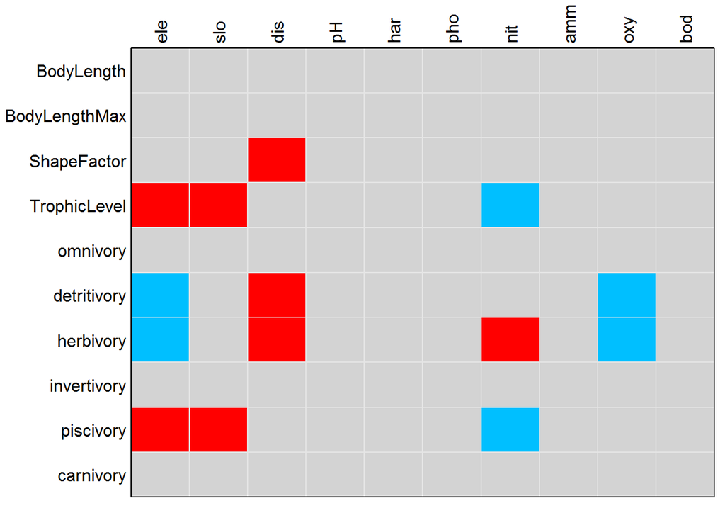

```r
plot(fourth.doubs2,
     stat = "G")
```

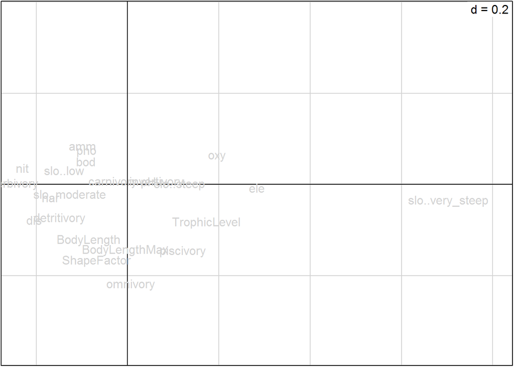

```r
# Biplot combining RLQ and fourth-corner results
plot(fourth.doubs.adj,
     x.rlq = rlq.doubs,
     alpha = 0.05,
     stat = "D2",
     type = "biplot"
     )
```

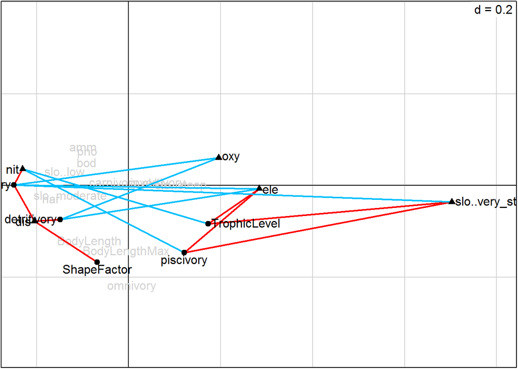

```r
plot(fourth.doubs2,
     x.rlq = rlq.doubs,
     alpha = 0.05,
     stat = "D2",
     type = "biplot"
     )
```

## 6.12 结论

排序, 查看生态数据信息的一种方式, 同时也是在涉及多个数据矩阵的多环境变量中揭示,解释,检验和模拟生态关系的有力的方法家族.

> 本书汇总了作者认为最重要且最有用的方法.

| Name, acronym | Use (examples) | R functions(packages) | Data; implementation; limitations |
| --- | --- | --- | --- |
| A. Asymmetric analyses – 非对称分析 |  |  |  |
| Redundancy analysis, RDA | Predict Y with X (Variation partitioning) | rda{vegan} / varpart{vegan} | All types; species data with prior transformation; m < (n-1). Linear model. |
| Canonical correspondence analysis, CCA | Predict Y with X | cca {vegan} | Y: species abundances; X: all types; m < (n-1); unimodal response to latent variables. |
| Linear discriminant analysis, LDA | Explain classification with quantitative variables | lda{MASS} | Y: classification; X: quantitative variables. Linear model. |
| Principal response curves, PRC | Model community response through time in controlled experiments | prc{vegan} | Y: community data; factor “treatment”; factor “time”. |
| Co-correspondence analysis (asymmetricform), CoCA | Predict one community on the basis of another | coca{cocorresp} | Y: data for community 1; X: data for community 2; both at the same sites. Unimodal response to latent variables |
| B. Symmetric analyses – 对称分析 |  |  |  |
| Co-correspondence analysis (symmetric form), CoCA | Optimized comparison of two communities (descriptive approach) | coca{cocorresp} | Y1: data for community 1; Y2: data for community 2; both at the same sites. Unimodal response to latent variables |
| Canonical correlation analysis, CCorA | Common structures of two data matrices. | CCorA{vegan} | Two matrices of quantitative data. Linear model. |
| Co-inertia analysis, CoIA | Common structures of two or more data matrices. | coinertia{ade4} | Very general and flexible; many types of data and ordination methods. |
| Multiple factor analysis, MFA | Common structures of two or more data matrices. | mfa{ade4} / MFA{FactoMineR} | Simultaneous ordination of 2 or more weighted tables. Mathematical type must be homogeneous within each table. |
| RLQ analysis, RLQ | Species traits related to environmental variables | rlq{ade4} | 3 tables: species-by-sites, sites-by-environment; species-by-traits |
| Fourth-corner analysis | Species traits related to environmental variables | fourthcorner, fourthcorner2{ade4} | 3 tables: species-by-sites, sites-by-environment; species-by-traits |